# Odling

# Plantering

**När**:

Krukodlade träd (då de har intakta rötter) kan planteras när som helst så länge marken inte är frusen. Hösten ända fram till vintern är en bra tid. Då börjar rötterna växa när det på våren blir några värmegrader i jorden. Trädet kan då rota sig tidgt på odlingssäsongen.

**Var**:

- Jordtyp:
  - Väldränerad, medelfuktig och lucker jord (för att rötterna skall kunna etablera sig och sedan undvika att stå alltför blött).
  - Undvik att plantera på mycket tunga lerjordar (kompakt, blött).
  - Ungefär neutralt pH.
  - Gärna mullrik, kalkrik jord.
- Läge:
  - Soligt, för att ge bra med frukt. Sex till åtta (8-10?) timmars direkt solljus behövs. Om platsen är i skugga före kl 16 vid midsommar är den troligen för skuggig.
  - Plantera ej träd för nära huset. Rotsystemet kan skada grunden och rörsystem. Vid storm kan trädet falla och skada det. Fem till sju meter anges ibland som ett lämpligt säkerhetsavstånd. Rötternas utbredning blir kring två-tre gånger trädets höjd.
  - Avståndet till pollineringsträden (vilka blommar samtidigt) bör vara max 20-25 meter.

Surkörsbär klarar blötare jordar bättre än sötkörsbär (men de föredrar väldränerade). De klarar sig vanligen också bra i halvskugga. Olika *grundstammar* skiljer sig också åt avseende vilka jordar de klarar.

**Hur**:

Principen är att rötterna skall ha lucker, väldränerad jord att växa i och att rotstammen skall hamna ovan marknivå även efter att jorden sjunkit ihop. Man kan sikta på att bygga en kulle som når 20-25 cm ovan den omgivande marken.

1. Ställ roten i vatten i en halvtimme innan den planteras.
2. Gräv en grop, 1.5-2 m diameter, djup 40-50 cm.
3. Luckra upp botten och sidorna av gropen.
4. Blanda den befintliga jorden med tex planteringsjord (ej djupare än 50 cm). Sandig eller lerhaltig jord blandas med 1/3 näringsberikad torv (fuktas väl innan), barkmull, kompost- eller planteringsjord.
5. Måtta så att rothalsen hamnar ca 10 cm högre än **omgivande** marknivå, så att det finns sjunkmån. Den bör även vara 5-10 cm ovan jordytan i planteringsgropen.
6. Lägg gärna mineraljord (makadam, grus eller sand) som rotsystemet kan stå på.
7. Luckra upp rötterna med fingrarna.
8. Placera trädet i gropen.
9. Fyll på med jord uppblandad med tex plantjord (hur mycket?) till två tredjedelar av klumpens höjd och trampa till den lätt. Fyll sedan på med mer jord och trampa till lätt.
10. Vattna ordentligt och låt vattnet sjunka undan.
11. Bind upp trädet till en eller två trästörar. Använd ett bindmaterial som inte skaver i barken när trädet svajar.
12. Sätt på gnagskydd.

Vid höstplantering, vänta till våren och följ det vanliga gödslingsschemat. Vid vårplantering gödsla tidigt på sommaren (?).

**Varför man bör undvika att plantera för djupt:**

- Rothalsen är känslig för bakterie- och svampangrepp.
- Om jorden sjunker bildas en grop där vatten kan samlas och på vintern frysa och skada stammen.
- Jord med hög mullhalt sjunker ihop (torv, kompost, och annat organiskt material bryts ner med tiden).
- Organiskt material som hamnar mer än ca 50 cm under markytan bryts ner utan tillgång till syre.

**Avstånd mellan träden**:

- Om de beskärs buskliknande: 4.5 m
- Om de beskärs i pyramidform: 3.5 m

**Etableringsbeskärning**: Se avsnittet om beskärning nedan.

# Skötsel de första åren

Nyplanterade träd torkar och dör om det inte är fuktigt i jorden. De har nytta av gödsling.

- Vattna minst en gång i veckan (men inte dagligen) hela första sommaren. En kraftig regnskur ger inte tillräckligt med vatten för att det skall tränga ner ordentligt till rötterna. Även efterföljande år 2-3 bör man se till att jorden är lagom fuktig. Fullvuxna träd behöver också fukt i jorden under sommaren för att producera frukter av god kvalitet.
- Kontrollera att jorden är fuktig ner till 15-20 cm, gräv ett hål ett dygn efter bevattning och känn efter.
- Håll undan gräs och ogräs runt trädet, de konkurrerar om vatten. Fortsätt med detta de första 7-8 åren.
- Inspektera för angrepp av sjukdomar eller insekter.
- Beroende på *grundstam* behöver trädet fortsatt stöd av en stör de första åren eller hela livet.
- Kontrollera hur årsskotten växer. Om de stannar i tillväxt tidigt under sommaren beror det vanligen på för litet vatten, svampangerepp eller näringsbrist. Tillskott av kalk och kompost år 1-2 kan hjälpa. År 2-3 förväntas årsskotten i medeltal växa minst ca 9 cm, om inte kan det bero på närings- eller vattenbrist.
- Tag bort alla utom två till fyra bukettgrenar/fruktknippor det första året. Detta hjälper trädet att satsa på rottillväxt.
- År två till tre kan körsbären beskäras försiktigt för att ge dem önskad form.

# Gödsling

## Några principer

- Unga träd har nytta av gödsel de första tre åren (längre i sand- eller grusjord) för att stimulera tillväxt. Om du använt gödslad jord (tex planteringsjord) vid planteringen räcker detta som näring över första sommaren.
- Den bästa tiden att gödsla är tidigt på våren. Gödslar man under senvåren eller sommar gynnas frodig tillväxt, frukten hämmas och trädet blir sårbart för vinterskador då det fördröjer starten av vintervilan.
- Om jordens pH är för lågt (< 6.0) kan trädet ha svårt att ta upp näring. Årlig kalktillförsel kan då användas för att höja pH.
- Kväve (N) stimulerar tillväxt av grenar och löv, men för mycket kan ge överdriven tillväxt och svaga grenar på bekostnad av blomning och frukt.
- Fosfor (P) stimulerar rottillväxt.
- Kalium (K) är till nytta för knoppning och fruktkvalitet.
- Använd helst näring som är anpassad för fruktträd. Annat gödsel har vanligen lägre andel kväve och högre fosfat.
- Undvik att lägga gödsel mot stammen.
- Mängden gödningsmedel som ska appliceras beror på antalet år sedan trädet planterades i din trädgård.
- Följ anvisingarna på förpackningen angående mängd. Vid tvekan, tag hellre för litet än för mycket. Var försiktig med doseringen av NPK, som är ett koncentrerat gödsel. Överdosering kan göra att växterna blir “brända”.

## Exempel på gödslingsschema

Gödsla en gång tidigt på våren och en gång på hösten. Eventuellt även på försommaren om nytillväxten är dålig (?).

**Vår**: Gödsla varje vår (när nytillväxten startar) med tex mullrik kogödsel (stimulerar blomning, skörd och övervintring).

**Försommar (eventuellt)**: Naturgödsel eller mineralgödsel NPK.

**Höst**: PK-gödsel eller liknande, tex “Höstgödsel PK 11-21”.

- Använd gödning **utan** kväve (N). Kvävetillförsel på hösten kan “lura” trädet att det är längre säsong och det avmognar då inte i tid.
- Det är fosfor (P) och kalium (K) som gynnar rotutveckling, samt blomning och fruktsättning det kommande året. Det gör även växten mer vinterhärdig.

**Vår eller höst:** Om nytillväxten är mindre än 6-8 tum per år, överväg att tillsätta ett balanserat granulerat gödningsmedel med högre andel kväve, till exempel en NPK 10-10-10 (%).

# Bevattning

Torka under celldelningsperioden ger små bär och gör att karten faller. Torka under de fem veckor som föregår skörden ger små bär. Ojämn vattentillgång från den period då bären börjar få färg ger spruckna bär.

- Håll jorden lagom och jämnt fuktig.
- Det är särskilt viktigt att undvika torka de första åren.
- Vattna rikligt under torra somrar.
- ca 20-30 lit en gång i veckan eller oftare

# Beskärning

Beskärning görs av olika skäl beroende på trädets ålder. Den första våren efter plantering görs “etableringsbeskärning” för att stimulera rottillväxt. När trädet är ungt, dvs 1-3 år (kanske upp till 5 år), görs “uppbyggnadsbeskärning” för att ge trädet önskad form och begränsa höjden. Därefter följer “underhållsbeskärning” som främst syftar till att ta bort döda eller skadade grenar som kan bidra till sjukdom samt att bibehålla ljusgenomsläpp och därmed bättre fruktkvalitet. Underhållsbeskärning kan eventuellt också göras för att få nya grenar som bär mer frukt, då fruktsättningen minskar på äldre grenar (> ca 5 år). Körsbär bör beskäras med försiktighet.

## Teorin bakom beskärning

**Apikal dominans**

I toppen av skotten produceras hormonet auxin. Det förs med gravitationen ned längs skottet och grenen. Auxin hämmar tillväxen av laterala (sidoväxande) skott, så kallad “apikal dominans”. Detta påverkar hur många sidoskott som tillväxer (mer auxin hämmar antalet), med vilken vinkel de växer (auxin ökar vinkeln), och deras längd. Genom att skära bort toppen av ett skott minskar man tillfälligt auxinet i den grenen och därmed den apikala dominansen, varvid laterala knoppar stimuleras till att växa ut som skott.

Grenar och rötter står i ett ömsesidigt beroende av varandra. Rötterna förser grenarna med vatten och näringsämnen, grenarna producerar kolhydrater som används av rötterna. Balansen mellan rötter och grenar regleras av hormoner, såsom auxin. I rotsystemet produceras cytokininer som främjar tillväxten och det är egenligen balansen mellan cytokininer och auxin (och gibberelin från nyutslagna löv) som styr tillväxten.

Hur en gren växer och hur den reagerar på beskärning påverkas av den apikala dominansen. Apikal dominans är starkast i de grenar som växer lodrätt, minskar i de grenar som växer med 45-60 graders vinkel och upphör om grenen växer horisontellt.

**Effekten av auxin på trädets växtsätt**

Normalt är det toppskott på en lodrät gren som har den största tillväxten. Varje sidogren under denna växer progressivt långsammare och de lägst belägna knopparna växer ej till skott. Detta kan bero på att auxin från de ovanliggande knopparna och skotten ansamlas ju längre ner man kommer.

Eftersom auxin fördelas beroende på gravitationen ansamlas det mer på undersidan av grenen desto mer horisontellt den växer. Vid en vinkel på 0-60 grader utvecklas nya skott ganska symmetriskt runt grenen, men i mer horisontella grenar tenderar skotten att bildas på ovansiden av grenen, där auxinkoncentrationen är lägre. Det är orsaken till att “vattenskott” (lodräta skott som har stark apikal dominans) gärna bildas på ovansidan av horisontella grenar.

Vinkeln med vilken en gren växer avgörs tidigt under det första året den tillväxer (fram tills dess den nått ca 10 cm). När fyra eller fler skott finns ovanför en ny gren blir vinkeln på grenen horisontell (50-90 grader). När det inte finns några skott ovanför grenen får den istället en smal vinkel/upprätt växtsätt (0-40 grader). Det skott som är längst ut på grenen får ofta ett konkurrerande skott med spetsig vinkel mot det första.

**Effekten av beskärning är olika beroende på grenens vinkel**

Om en upprätt gren beskärs ökar lateraltillväxten ner till ca 25 cm från snittet. För grenar i 45 till 60 graders vinkel sker tillväxten längre ner/närmare stammen. Ju mer upprätt den beskurna grenen är, desto mer kraftigväxande (och lövrika?) blir de ersättningsskott som kommer. Horisontella grenar kan vid beskärning skjuta fler “vattenskott”, dvs lodrätt växande skott utan sidoskott.

Tar man bort den apikala dominansen med beskärning blir de skott som tillväxer mer upprätta, med smalare vinklar. Trädet får även ett mer upprätt, smalare växtsätt, jämfört med hur trädet växer utan beskärning.

**Fotomorfism och gravimorfism**

Skott böjer sig när det finns en gradient av auxin inom skottet. Auxin gör att cellerna blir längre men hormonet förstörs av ljus. Cellerna på skottets mörkare sida blir längre pga att det finns mer auxin där och skottet böjer sig då mot ljuset, sk fotomorfism.

På liknande sätt gör gravitationen att auxin ansamlas i undersidan av horisontellt växande grenar, vilket ökar längdtillväxten av cellerna där och toppen av grenen böjer sig uppåt.

**Knoppar**

Knoppar kan vara “vegetativa” (ger grenar och löv) eller “reproduktiva” (ger blommor och frukt), eller hos vissa arter (tex vissa äppelsorter) blandade. Blomknopparna är större och mer rundade. Högt kväveinnehåll i skotten hämmar utvecklingen av blomknoppar. Mild stress, såsom böjning eller vattenstress kan stimulera utvecklingen av blomknoppar. För att få frukter av god kvalitet krävs en balans mellan mängden löv och blomknoppar. Beskärning av toppskottet gör att knoppar som skulle blivit blomknoppar istället blir vegetativa.

**Typer av beskärning**

Det finns två grundläggande typer av beskärning, “heading” och “thinning” (kapning och gallring?).

*Kapning*, där en del av skottet eller grenen tas bort, stimulerar tillväxt längst ut, nära snittet (vanligen utvecklas de 3-4 knopparna närmast nedanför snittet till skott). Kapning kan därför göra att nytillväxten av grenar kommer längre ut än önskvärt. Effekten av kapning beror på trädets ålder och grenens typ. Kapning av ettårigt trä ger en stark lokal respons, då tre till fyra av knopparna nedom snittet utvecklas till kraftigväxande, upprätta skott med smala vinklar. Den kapade grenen blir styvare. Kapning på unga träd har en negativ effekt på tillväxt och fruktsättning som varar i fem år. Kapning används på nyplanterade träd för att ge starka laterala grenar som sedan utgör trädets stödstruktur.

Vid *gallring* tas ett helt skott eller gren bort vid basen (dvs vid krongrenen). Apikal dominans behålls då genom att en del toppskott bevaras. Nytillväxten sker därför i de befintliga skott som lämnats orörda och lateral tillväxt hämmas fortfarande i kvarvarande grenar. Gallring ger ett mer naturligt växtsätt än kapning. Det görs främst för att öka ljusgenomsläppligheten och undvika trängsel i kronan. Det kan också användas för att ta bort upprättväxande skott och grenar som ej bär frukt. Liksom kapning används gallring för att forma det unga trädet. Hos vuxna träd upprätthåller gallring ljusgenomsläpp i kronan, och förbättra fruktstorlek och -kvalitet.

Flera små snitt ger större antal nya skott och mer reduktion av fruktsättning än färre, större snitt.

Table 1: Effekt av olika beskärningssätt

| Variabel | Gallring | Kapning |
| --- | --- | --- |
| Apikal dominans | Liten effekt på kvarvarande grenar | Toppskottet borttages, knoppar frigörs |
| Skottbildning | Färre vegetativa skott | Ökat antal och längd |
| Sporrbildning | Ökad | Minskad |
| Trädets form | Begränsad effekt | Dramatisk effekt |
| Trädets växtsätt | Naturligt högt och glest | Kompakt och upprätt |
| Fruktsättning | Begränsad effekt | Minskning |
| Kolhydratreserver | Begränsad effekt | Minskning |
| Näringsämnen i frukt | Begränsad effekt | Minskat kalcium, magnesium; ökat kväve |
| Lokal stimulans | Stimulerar ett fåtal skott | Stimulerar ett flertal skott |

**Följder av beskärning**

Vissa växter blöder mycket efter beskärning. De kan beskäras när det finns aktivt växande löv, dvs vår eller försommar, vilket minskar blödningen och på så vis gör att såret kan läka snabbare.

Beskärning minskar trädets totala massa. Eftersom beskärning ökar den vegetativa tillväxten nära snittet ger det illusionen att beskärning stimulerar tillväxt, men ser man på hela träder ger årlig beskärning alltid mindre total massa än om trädet inte beskärs.

Beskärning minskar trädets slutliga storlek. Minskningen är större ju mer det beskärs. Borttagning av en gren tar bort den reserv av kolhydrater och kväve som lagrats där, samt reducerar lövverkets storlek och antal tillväxtpunkter. Det minskar också rötternas tillväxt, som fördröjs tills nya skott kommit.

När man beskär tas knoppar bort som skulle kunnat bära frukt. Beskärning minskar således mängden frukt, men ökar storleken på de kvarvarande frukterna genom att mängden löv per frukt ökar. Det ger även mer ljusgenomsläpp vilket ökar den röda färgen och sockerinnehållet i frukterna.

Beskäring av en ung planta stimulerar tillväxten av bladbärande skott och trädet börjar producera frukt senare i livet.

Beskärning *på sommaren* tar bort blad och minskar därför fotosyntesen som ger trädet energi. Detta kan leda till att frukternas storlek och sockerinnehåll minskar, samt att stammen och rötterna växer mindre.

Beskärning ökar risken för köldskador (sker vanligen vid -23 till -49 grader). Den ökade känsligheten är som störst de första 48 timmarna men håller i sig åtminstone två veckor.

Grenar stannar på den höjd där de växer ut. Det betyder att en gren som växer ut på en viss höjd fortfarande efter ett antal år är kvar på samma höjd.

## Beskärningens syfte

**Varför beskära?**

- Sötkörsbär tenderar att få långa, upprätta grenar utan frukt. Med beskärning kan man gynna de mer horisontellt växande, fruktbärande grenarna.
- Surkörsbär får det mesta av sin frukt på fjolårsskotten, så om de inte beskärs kommer bären längst ut på alltför långa grenar (?).
- Forma trädet de första åren och ge det en stark grundstruktur som också ger förutsättningar för frukter av god kvalitet (bla genom att undvika en alltför tät krona). Man eftersträvar då vanligen vidare grenvinklar.
- Begränsa trädets höjd och utbredning (underlättar skörd och att lägga på nät som skydd mot fåglar).
- Borttagning av döda eller sjuka grenar minskar risken för sjukdom.
- Förhindra att grenar skaver mot varandra (skapar sår som kan ge fäste åt infektioner).
- Behålla ljusgenomsläpp i kronan som förbättrar frukternas kvalitet. En alltför tät krona kan också ge försämrad fruktproduktion och mer kvardröjande fukt som ökar risken för sjukdomar.
- Eventuellt: Upprätthålla balans mellan något äldre fruktbärande grenar och yngre ersättningsgrenar.

**Varför vara försiktig med beskärning?**

- Risk för bakteriesjukdom/röta som kommer in i snittytan.
- Beskärs trädet för hårt kan det bli “vattenskott” som inte bär frukt och som ger en för tät krona.
- Om kvoten mellan antal blad och frukter blir för litet kan bladen inte försörja frukterna tillräckligt.
- Beskärning minskar trädets totala tillväxt och antalet frukter över tid.

## Beskärningsteknik

**Grunder**

- Körsbärsträd tål inte för hård beskärning. Överväg därför noga hur mycket som behövs.
- Gör beskärningen i torr väderlek, det minskar risken för bakterieangrepp innan såret har förseglats.
- Använd en vass och ren sekatör.
- Läs om skillnaden mellan gallring och kapning ovan.
- Lägg snittet en bit ovanför en utåtriktad gren eller öga. Grenen växer dit ögat pekar.
- Gör snittet med lutning bort från ögat, så att vatten kan rinna av.
- Om du **gallrar bort** en gren/skott, dvs beskär vid stammen, skär så nära grenkragen som möjligt men låt grenkragen sitta kvar så läker det snabbare. Skada inte grenkragen. Lämna inte tappar.
- När du **kortar ner** ett ungt skott, spara en halv cm ovanför den sista knoppen, för att knoppen skall undvika att torka in. Den nya tillväxten kommer att ske i den riktning den yttersta kvarvarande knoppen sitter.
- Tag inte bort grenar som är tjockare än ett finger.

**När beskära?**

Det verkar råda delade meningar om när körsbär bör beskäras. Att etableringsbeskärning görs på våren tycks allmänt rekommenderat. Avseende beskärning under åren därefter är rekommendationerna olika. Några faktorer som kan beaktas:

- Beskärning när det finns växande löv minskar blödningen från snittet.
- Beskärning som fördröjs en tid efter blomning minskar energireserven och vitaliteten i tillväxten. Det kan störa utvecklingen av blomknoppar kommande år.
- Vid beskärning under sensommaren läker snitten snabbare än vid beskärning under trädets vilande period.
- Risken för bakteriengrepp är sannolikt störst på hösten, varför det är rimligt att undvika beskärning då.
- Svampen som ger silverglans trivs bäst när det är fuktigt och 2-21 grader varmt. Under de varma sommarmånaderna hämmas svampen och träden har då lättare att skydda sig genom att utsöndra rikligt med sårgummi.
- Vinterbeskärning kan öka risken för köldskador och efterföljande sjukdomsangrepp.
- Beskärningen bör göras vid torr väderlek, för att minska risken för bakterieangrepp och silverglans.

Sammantaget verkar följande rimligt:

- Etableringsbeskärning (första året): Våren, kring lövsprickning. Kan eventuellt kompletteras under JAS-perioden.
- Uppbyggnadsbeskärning (år 1-3): Våren, kring lövsprickning eller tidigt under JAS-perioden.
- Underhållsbeskärning (därefter): Under JAS-perioden, så tidigt som möjligt efter skörd.
- Undvik beskärning under höst/vinter (eventuellt även sensommar?)
- Om en gren blir skadad eller sjuk rekommenderas att den kapas ner till friskt trä så snart som möjligt (helst vid torr väderlek), oavsett säsong. Ett rent snitt är bättre än ett ojämnt brott.

**Trädets form**

Det finns olika sätt att beskära körsbärsträd. Vissa syftar till att snabbt ge hög avkastning.

En grundläggande princip är att välja några (tre till fyra) “krongrenar” som gynnas och tillsammans med den centrala ledargrenen kommer att utgöra trädets grundstruktur. Dessa grenar kapas inte igen efter att de fått sin önskade form och utbredning. Krongrenarna bör vara jämnt fördelade runt stammen och ha en vinkel kring 45 grader. Det finns olika rekommendationer angående längden på krongrenarna (25-60 cm). Ibland väljer man att skapa ett andra “lager” av krongrenar längre upp längs stammen.

## Etableringsbeskärning

**Varför**:

Rotsystemet är vid plantering underutvecklat i förhållande till kronan. Etableringsbeskärningen gör att rotsystemet får möjlighet att komma ikapp och bli tillräckligt stort för att kunna försörja grenarna med vatten och näring. Det är också viktigt att trädets resurser satsas på ett mindre antal starka knoppar med rätt placering. Risken är annars att trädet blir glest och spretigt, får dålig tillväxt och få skott.

Redan här börjar beskärningen påverka trädets framtida form. En ledargren och omgivande blivande krongrenar bör väljas ut och gynnas.

**När**:

Etableringsbeskärning beskärning kan göras direkt vid vårplantering (vissa menar att man bör vänta till efterföljande vår). Den görs alltid på våren, innan knopparna har börjat slå ut. Även de träd som planterats på hösten etableringsbeskärs på våren. Vid beskärning på sommaren stimuleras inte tillväxten på samma vis. Trädet kan vara beskuret på plantskolan innan leverans och man får då anpassa etableringsbeskärningen efter detta.

Om trädet som planteras är 5-6 år har plantskolan redan gjort en beskärning, då räcker det att vid plantering ta bort skadade grenar.

**Hur**:

- Identifiera den centrala ledargrenen. Om den har en konkurrerande ledargren i snäv vinkel, tag bort den.
- När skotten är 5-10 cm långa kan några av de mer utåtväxande väljas som krongrenar. De två-tre *uppåtväxande* skott som ofta växer strax nedanför ledaren tas bort och de lägre skotten med *bredare vinklar* behålls som krongrenar.
- Välj tre till fyra krongrenar (kan vara bra att ha en extra ifall en av dessa skulle skadas det kommande året). De bör:
  - Vara jämnt spridda runt stammen.
  - Vara belägna minst 50 cm från marken.
  - Växa med en vinkel på 45-60 grader.
- Saknas skott med breda vinklar kan en klädnypa sättas om huvudstammen och tryckas ner över sidoskottet så att det tvingas växa mer utåt. Detta måste göras innan skottet hårdnar. Klädnypan tas bort efter 3-4 veckor.
- Saknas tillräckligt med sidoskott för att bilda tre krongrenar låter man ett sidoskott från någon av de befintliga skotten/grenarna växa till sig istället. Ett alternativ kan kanske vara att “snitta” (se “knep” nedan).
- Börja med att klippa bort eventuella konkurrensskott/dubbelgrenar till de du tänkt spara.
- Korta de blivande krongrenarna så att de är 25-30-40(-60?) cm långa från mittenstammen (eventuellt vänta tills de är ca 60 cm innan detta görs, vilket kan vara nästkommande år). Gör det på ett sätt så att det översta ögat/knoppen pekar bort från centrum.
- Korta den centrala ledaren så att den är ca 20 cm högre än krongrenarna om dessa beskurits (alternativt kapa det vid önskad höjd, tex 1.5 m, se upbyggnadsbeskärning nedan).
- Om krongrenarna ej beskärs detta år, tag bara bort några cm av toppen på den centrala ledaren. Detta görs för att begränsa trädets höjd och för att stimulera lateral tillväxt.
- Om det endast finns två krongrenar och du beskär den centrala ledaren, se till att den högst belägna knoppen/skottet sitter i lämplig riktning för att bilda en till krongren.
- Övriga skott klipps av intill stammen, så att bara den centrala ledaren och de tilltänkta krongrenarna finns kvar.
- Följ trädets utveckling under uppväxttiden.
- Plommon och körsbär beskärs så litet som möjligt efter etableringsbeskärningen. Man tar främst bort grenar som växer inåt i kronan eller som skaver på andra grenar.
- Tag bort nybildade frukter för att prioritera annan tillväxt.

## Rensning

Rensning ingår i både uppbyggnadsbeskärning och underhållsbeskärning:

- Börja med att helt ta bort helt döda eller sjuka grenar.
- De som växer rakt nedåt.
- De som korsar varandra.
  - Om två grenar korsar eller gnager mot varandra, ta bort den ena.
  - Om två grenar växer parallellt, nära varandra, ta bort den ena.
- De som växer snett/inåt eller uppåt längs stammen, så att de inte växer in i kronan.
- Gallra bland vattenskott (under sensommar/höst).
  - Ta bort ungefär en tredjedel av dessa varje år. Tar man bort alla riskerar de att återkomma.

Vattenskott: Sitter på ovansidan av horisontellt växande grenar och bildas vid för hård beskärning eller annan stress. De växer lodrätt och brukar inte ha sidoskott. De kan användas som nya krongrenar om de sitter på en ung gren.

## Uppbyggnadsbeskärning

**Varför**:

Görs på yngre träd. Trädet formas under de första (1-3?) åren. Principen är att forma trädet, gynna utåtväxande grenar och undvika grenar med för snäv vinkel. Här avgörs också om trädet skall få en korgform (ger lägre träd) eller ha en genomgående huvudstam.

**Hur**:

Enligt de flesta rekommendationer skall körsbär beskäras försiktigt, så att man efter etableringsbeskärningen endast tar bort skadade, skavande eller konkurrerande grenar. Dock finns en del andra metoder beskrivna (se “spansk buske” nedan).

- Beskär så litet som möjligt.
- Börja med rensning (se ovan).
- Bevara de tre till fyra grenar som skall bli krongrenar. Tag bort de grenar som sitter lägre än krongrenarna, så nära stammen som möjligt, men bevara kragen.
- Ibland väljer man att beskära skotten som kommit från krongrenarna (de “primära” grenarna) så att en andra omgång strukturgivande grenar växer från dessa (sk “sekundära” grenar). Beskär då de sekundära grenarna (gärna när de blivit >60 cm långa) så att de är i ungefär samma höjd och är ca 25-35 cm längd från föregående beskärningspunkt. Välj dock ett ställe där ögat/knoppen som hamnar längst ut är riktat utåt, så att det inte sedan växer inåt i kronan. Enligt vissa sparas endast ett eller två sidoskott från krongrenarna och resten tas bort.
- Ibland väljer man att skapa ett andra “lager” med tre-fyra krongrenar som utgår från den centrala stammen, ca 60 cm ovanför det första. Man väljer då grenar som inte kommer att tyngas ner mot grenar i det första lagret.
- Eventuellt: Korta ner (tag bort ca två tredjedelar av längden alternativt spara fyra knoppar) långa (>22 cm) årsskott de första 4-5 åren, ger mer kompakt krona och undviker kala grenpartier. Därefter mer sällan, kanske vartannat år.

## Underhållsbeskärning

**Varför**:

Efter att uppbyggnadsbeskärningen har format trädet görs underhållsbeskärning där man främst tar bort döda eller skadade grenar. Vissa argument finns för att göra ytterligare underhållsbeskärning:

- Körsbärsträd bär frukt på grenar som är ettåriga eller äldre, samt på sporrar från äldre grenar. När grenen är fyra år eller äldre minskar fruktproduktionen. Det kan därför eventuellt vara önskvärt att beskära (ta bort?) äldre grenar för att stimulera nya grenar. De grenar som formar trädets grundstruktur bör förstås lämnas. Denna beskärning görs under JAS-perioden, efter skörd (?).
- En alltför tät krona kan ge sämre kvalitet på frukterna. Beskärning genom gallring kan göras för att bevara ljusgenomsläpp.

Surkörsbär är vanligen mindre starkväxande och mindre uppåtväxande än sötkörsbär, varför de som vuxna träd blir mindre. De kan dock behöva beskäras för att förnya grenarna så att de bär frukt.

**Hur**:

- Beskär så litet som möjligt.
- Börja med rensning (se ovan).
- Eventuellt: Om kronan är för tät kan man välja att gallra genom att ta bort svaga grenar och nytillkomna sidoskott. I första hand de som växer in mot kronan.
- Eventuellt: Tag bort nya skott från huvudstammen.
- Eventuellt: Kapa den yttersta tredjedelen av nya grenar vart annat år för att begränsa höjd.

Körsbär på svagväxande grundstammar har en benägenhet att blomma rikligt. Det kan ge för mycket frukt för att trädet skall må bra. Om detta sker bör du därför tunna ut genom att antingen ta bort frukterna när de börjat växa (klipp av klasarnas stam), eller på liknande vis under blomningen. Tag företrädesvis bort de klasar som växer från grenarnas undersida.

## Knep

**Snittning?**

Om man vill stimulera tillväxt av horisontella grenar kan man skära ett litet sår, ca 2-3 mm brett, genom barken stax ovan en vilande knopp. Då hindras auxinet från att komma uppifrån och knoppen kan växa till ett skott. Det stimulerar mer lågväxande, horisontella, fruktbärande grenar. Detta fungerar endast de första åren (?).

**Borttagning av löv?**

Genom att på sensommaren dra bort löv från en sektion av ett skott kan laterala knoppar stimuleras att växa ut som skott därifrån.

**Toppning?**

En metod som kan användas för att hantera trädets storlek och form är “toppning”. Om nya skott är 30 cm eller mer på försommaren tar man bort den nytillväxt som överstiger ca 25 cm.

**Böja ner grenarna?**

Ju mer upprätt en gren växer, desto mer bladtillväxt och mindre frukt. Genom att böja ut grenarna 30-60 grader kan man stimulera frukttillväxt.

Detta kan användas som en typ av “beskärning”. Den görs företrädesvis tidigt på våren, just före det att tillväxten börjar. Alla sidogrenar som behövs böjs ner till horisontellt läge (eller lägre) med hjälp av tyngder (tex vedträn). Mittenstammen böjs i en skarpare vinkel. Detta upprepas året efter med nya grenar. Oönskade grenar skärs bort. Efter ett år nedböjda håller de formen. Gradvis utböjning kan vara att föredra.

## Spansk buske

Det finns många olika sätt att beskära både sur- och sötkörsbär. Förutsatt att en vanlig grundstam används (som gör trädet mindre) kan nedanstående metod användas. För att stimulera fruktsättning?

*Första våren:*

- Om det planterade trädet är en “piska” utan grenar, beskär det i perioden mellan knoppbristning och blomning till 50-75 cm ovan marknivå (?). När grenar utvecklas, sära dem så att de växer med vid vinkel mot stammen. När de vuxit 50-60 cm, beskär dem till samma nivå (vilket bör motsvara ca 15 cm ovan beskärningen som gjordes vid plantering).
- Om det planterade trädet har bra grenar (3-4 st jämnt fördelade runt stammen), beskär dem det första året vid knoppbristning så att spetsarna är på samma nivå, ca 25-30 cm långa.

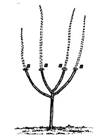

Spansk buske, etableringsbeskärning

*Andra våren:*

- När de “sekundära” grenarna blivit 50-60 cm långa, beskär dem (nära eller efter blomning) till samma nivå, ca 25 cm långa. När de “tertiära” grenarna blivit 50-60 cm, beskär dem på samma sätt (i nivå ca 25 cm ovan den föregående beskärningen). Denna tredje beskärning behövs kanske endast på starkväxande sorter.
- Glesa eventuellt ut kronan genom att avlägsna starkväxande, uppåtväxande grenar och lämna de svagare, mer horisontella grenarna, för att uppmuntra fruktbärning.

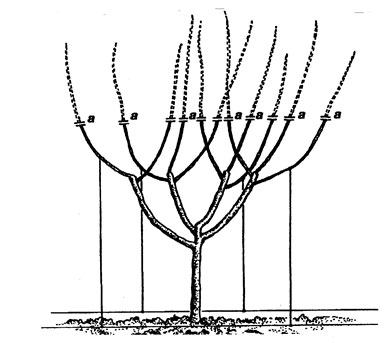

Spansk buske, andra beskärning

*Efterföljande år:* De sekundära och tertiära grenarna blir trädets stomme. Frukter utvecklas på de svagare grenar som växer från dessa. De bör förnyas regelbundet. Skär bort ungefär en fjärdedel av de fruktbärande grenarna regelbundet, efter skörd. Glesa ut starkväxande, uppåtväxande grenar för att bibehålla soltillgång. Till hösten, beskär trädtoppen till ca 2.5 m.

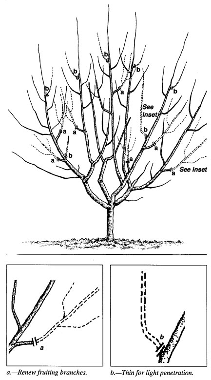

Spansk buske, fortsatt beskärning

## Sluthöjd

Kan hållas nere med beskärning. Utan beskärning (på svagväxande grundstam):

- Starkväxande: 5 till 7 m.
- Medelstarkväxande: 4 till 6 m.
- Buske: 150-300 cm.